# Chapter 3 Assignment

Jacob Smith

2022-09-09

```r
library(tidyverse)
```

##Question 1

```r
mario_kart <- read.csv("world_records.csv")
three_laps <- mario_kart %>%
  filter(type == "Three Lap")
non_rainbow <- three_laps %>%
  filter(track != "Rainbow Road")
rainbow_rat <- three_laps %>%
  filter(track == "Rainbow Road")
```

As to provide clarity between different tracks, I created 3 data sets which house information regarding three_lap records. The first houses all records. The second houses all records which dont include the infamous track rainbow road. The third houses all records for rainbow road.

##Question 2

```r
summary_rainbow <- rainbow_rat |>
  summarize(mean = mean(time), std_dev = sd(time))
summary_all <- non_rainbow |>
  summarize(mean = mean(time), std_dev = sd(time))
```

##Question 3

```r
three_lap_summary <- three_laps |>
  group_by(track) |>
  summarize(count = n())
three_lap_summary |>
  arrange(count)
```

| track | count |
| --- | --- |
| Bowser's Castle | 40 |
| Moo Moo Farm | 44 |
| Banshee Boardwalk | 55 |
| Koopa Troopa Beach | 56 |
| Wario Stadium | 71 |
| Kalimari Desert | 73 |
| Sherbet Land | 73 |
| Yoshi Valley | 74 |
| Royal Raceway | 77 |
| Luigi Raceway | 81 |

[output cut: 6 more lines]

I went back into the three_laps dataframe, and grouped by track, then used the ‘summarize’ function to count each individual record. As shown, it is Toad’s turnpike which had the most records

##Question 4

```r
Player_count <- three_laps |>
  group_by(player, track) |>
  summarize(count = n())
Player_count |>
  arrange(desc(count))
```

| player | track | count |
| --- | --- | --- |
| Penev | Choco Mountain | 26 |
| Lacey | D.K.'s Jungle Parkway | 24 |
| abney317 | Rainbow Road | 21 |
| MR | Toad's Turnpike | 20 |
| MR | Frappe Snowland | 18 |
| Penev | Toad's Turnpike | 18 |
| abney317 | Kalimari Desert | 16 |
| MR | Sherbet Land | 16 |
| abney317 | Choco Mountain | 15 |
| abney317 | Toad's Turnpike | 15 |

[output cut: 296 more lines]

As evidenced by the resulting tibble, Penev, on Choco Mountain, was the most prolific racer on any single map.

##Question 5

```r
Avg_time <- three_laps |>
  group_by(track) |>
  summarize(meantime = mean(time))


Avg_time |>
  arrange(meantime)
```

| track | meantime |
| --- | --- |
| Frappe Snowland | 77.13000 |
| Mario Raceway | 79.14805 |
| Yoshi Valley | 82.68122 |
| Moo Moo Farm | 88.41091 |
| Choco Mountain | 95.16024 |
| Koopa Troopa Beach | 96.64375 |
| D.K.'s Jungle Parkway | 101.40244 |
| Luigi Raceway | 103.84642 |
| Sherbet Land | 115.87932 |
| Toad's Turnpike | 121.66742 |

[output cut: 6 more lines]

Rainbow road has the longest average time with 275.63364 , compared to the next highest of Wario Stadiun which had an average time of 213.95873.

```r
best_times <- three_laps %>%
  group_by(track) %>%
  arrange(time) %>%
  slice(1) %>%
  select(track, time)
```

##Question 6

```r
three_laps <- three_laps |>
    mutate(long_duration =if_else(record_duration > 100, 1, 0))

long_durations <- three_laps |>
  group_by(player) |>
  summarize(count = n())

long_durations |>
  arrange(desc(count))
```

| player | count |
| --- | --- |
| MR | 174 |
| Penev | 172 |
| abney317 | 105 |
| Dan | 95 |
| MJ | 92 |
| VAJ | 52 |
| Booth | 51 |
| Zwartjes | 46 |
| Peter E | 44 |
| Lacey | 43 |

[output cut: 50 more lines]

## Question 7

```r
drivers <- read_csv("drivers.csv")
```

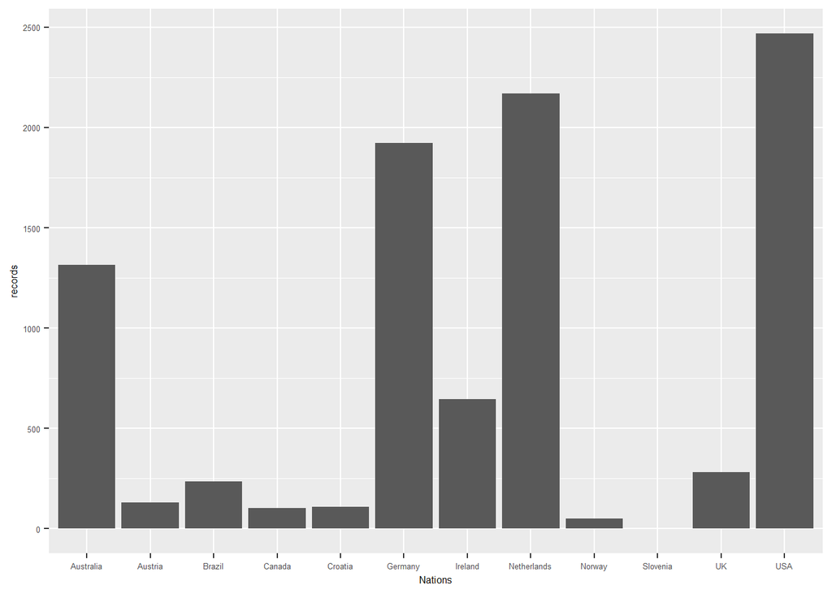

```r
laps_joined <- three_laps |>
  left_join(drivers, by = "player") |>
  drop_na()


ggplot(data = laps_joined,
       aes(x = nation)) +
  geom_bar() +
  labs(x = "Nations", y = "records") +
  theme(text = element_text(size = 6))
```

After loading in drivers, these were then joined with a left_join function so that the drivers matched up with their respective nations. However, this didn’t necessarily join all the functions correctly. In the drivers document, it separates drivers according to different years, I.E. Penez has entries for many different years, and their numbers of records change based on the years. Because left_join doesn’t connect multiple years, and the dates column using different formats, these don’t match up in the joined folder.

After plotting these into a bar-graph, its shown that the U.S. has the most records, with the netherlands being a close second.